# Homework 5

### Exercise 3

Perform an initial split of the data. Stratify by the outcome variable. You can choose a proportion to use. Verify that your training and test sets have the desired number of observations.

Next, use *v*-fold cross-validation on the training set. Use 5 folds. Stratify the folds by `type_1` as well. *Hint: Look for a `strata` argument.*

```r
pokemon_split <- initial_split(pokemon, strata = type_1, prop = 0.75)

pokemon_train <- training(pokemon_split)
pokemon_test <- testing(pokemon_split)
```

Why do you think doing stratified sampling for cross-validation is useful?

Stratified sampling will make sure that type_1 is evenly distributed in each fold to avoid bias in fitting.

### Exercise 4

Create a correlation matrix of the training set, using the `corrplot` package. *Note: You can choose how to handle the categorical variables for this plot; justify your decision(s).*

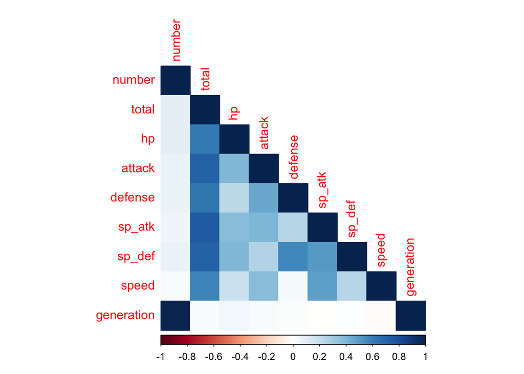

```r
library(corrplot)

pokemon_train %>% select(is.numeric) %>% cor() %>%
corrplot(type = 'lower',
         method = 'color')
```

What relationships, if any, do you notice?

The number has a very high correlation with generation, this make sense because new generation pokemon have higher number. And total has high correlation with all the predictors except generation, this is because a higher in individual ability must reflect as a higher in total.

### Exercise 5

Set up a recipe to predict `type_1` with `legendary`, `generation`, `sp_atk`, `attack`, `speed`, `defense`, `hp`, and `sp_def`.

- Dummy-code `legendary` and `generation`;
- Center and scale all predictors.

```r
# set generation as factor
pokemon_train$generation <- as.factor(pokemon_train$generation)
pokemon_test$generation <- as.factor(pokemon_test$generation)

# setup folds with a number of 5
pokemon_folds <- vfold_cv(pokemon_train, v = 5, strata = type_1)

# setting up recipe
pokemon_recipe <- recipe(type_1 ~ legendary + generation + sp_atk + attack + speed + defense + hp + sp_def, data = pokemon_train) %>%
  step_dummy(legendary) %>%
  step_dummy(generation) %>%
  step_center(all_predictors()) %>%
  step_scale(all_predictors(), -all_nominal()) %>%
  prep()
```

### Exercise 6

We’ll be fitting and tuning an elastic net, tuning `penalty` and `mixture` (use `multinom_reg()` with the `glmnet` engine).

Set up this model and workflow. Create a regular grid for `penalty` and `mixture` with 10 levels each; `mixture` should range from 0 to 1. For this assignment, let `penalty` range from 0.01 to 3 (this is on the `identity_trans()` scale; note that you’ll need to specify these values in base 10 otherwise).

```r
en <- multinom_reg(mixture = tune(),
                   penalty = tune()) %>%
  set_mode("classification") %>%
  set_engine("glmnet")

en_workflow <- workflow() %>%
  add_recipe(pokemon_recipe) %>%
  add_model(en)

en_grid <- grid_regular(
  penalty(range = c(0.01, 3),
          trans = identity_trans()),
  mixture(range = c(0, 1)),
  levels = 10)
```

### Exercise 7

Now set up a random forest model and workflow. Use the `ranger` engine and set `importance = "impurity"`; we’ll be tuning `mtry`, `trees`, and `min_n`. Using the documentation for `rand_forest()`, explain in your own words what each of these hyperparameters represent.

Create a regular grid with 8 levels each. You can choose plausible ranges for each hyperparameter. Note that `mtry` should not be smaller than 1 or larger than 8. **Explain why neither of those values would make sense.**

```r
rf_class_spec <- rand_forest(mtry = tune(),
                             trees = tune(),
                             min_n = tune()) %>%

  set_engine("ranger",importance = "impurity") %>%
  set_mode("classification")

rf_class_wf <- workflow() %>%
  add_model(rf_class_spec) %>%
  add_recipe(pokemon_recipe)

rf_grid <- grid_regular(mtry(range = c(1, 8)),
                        trees(range = c(5, 20)),
                        min_n(range = c(0, 10)),
                        levels = 8)
rf_grid
```

```
## # A tibble: 512 × 3
##     mtry trees min_n
##    <int> <int> <int>
##  1     1     5     0
##  2     2     5     0
##  3     3     5     0
##  4     4     5     0
##  5     5     5     0
##  6     6     5     0
##  7     7     5     0
##  8     8     5     0
##  9     1     7     0
## 10     2     7     0
## # ℹ 502 more rows
```

mtry means the number of parameters being considered at each split of the tree. min_n means the min number of observations at the terminal of the trees. mtry should in the range [min_n,max_n] to make sense cause you cannot exceed the range of the number of branches.

What type of model does `mtry = 8` represent?

It represents a bagging model.

### Exercise 8

Fit all models to your folded data using `tune_grid()`.

**Note: Tuning your random forest model will take a few minutes to run, anywhere from 5 minutes to 15 minutes and up. Consider running your models outside of the .Rmd, storing the results, and loading them in your .Rmd to minimize time to knit. We’ll go over how to do this in lecture.**

```r
# Fit Elastic Net
en_results <- tune_grid(
  en_workflow,
  resamples = pokemon_folds,
  grid = en_grid
)

# Fit Random Forest
rf_results <- tune_grid(
  rf_class_wf,
  resamples = pokemon_folds,
  grid = rf_grid
)
```

Use `autoplot()` on the results. What do you notice? Do larger or smaller values of `penalty` and `mixture` produce better ROC AUC? What about values of `min_n`, `trees`, and `mtry`?

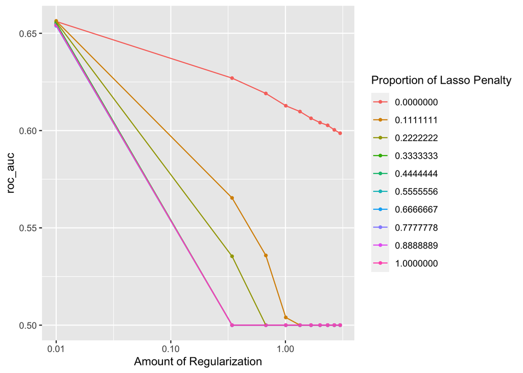

```r
# Visualize Elastic Net Results
autoplot(en_results, metric = "roc_auc")
```

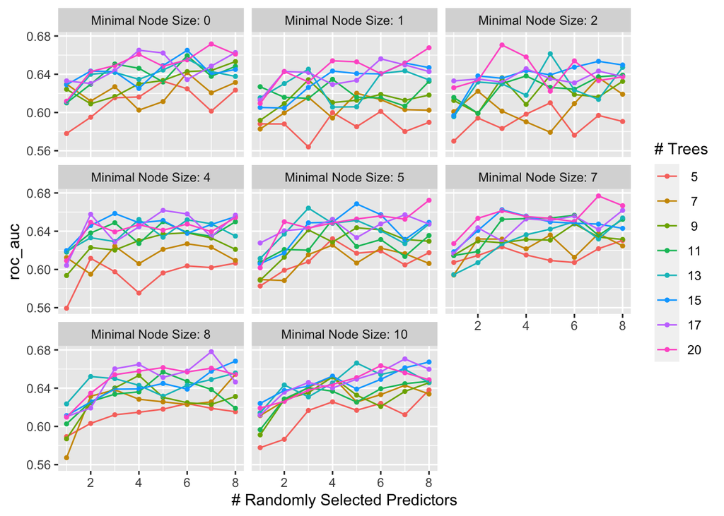

```r
# Visualize Random Forest Results
autoplot(rf_results, metric = "roc_auc")
```

The result shows that a smaller value of Lasso Penalty tends to have greater roc_auc, and the roc_auc of random forest is increase with increase of number of trees and minimal node doesn’t make that great contribution on the result. This make sense since smaller values for the Lasso penalty parameter would make the model more flexible, potentially capturing more patterns in the data. This could lead to a better classification performance as measured by ROC AUC. For the random forest, The plot shows that once we have sufficiently large minimal node sizes, the ROC AUC stabilizes.

What elastic net model and what random forest model perform the best on your folded data? (What specific values of the hyperparameters resulted in the optimal ROC AUC?)

```r
# Best Elastic Net Model
show_best(en_results, metric = "roc_auc")
```

```
## # A tibble: 5 × 8
##   penalty mixture .metric .estimator  mean     n std_err .config
##     <dbl>   <dbl> <chr>   <chr>      <dbl> <int>   <dbl> <chr>
## 1    0.01   0.111 roc_auc hand_till  0.656     5  0.0163 Preprocessor1_Model011
## 2    0.01   0     roc_auc hand_till  0.656     5  0.0166 Preprocessor1_Model001
## 3    0.01   0.222 roc_auc hand_till  0.656     5  0.0166 Preprocessor1_Model021
## 4    0.01   0.333 roc_auc hand_till  0.655     5  0.0164 Preprocessor1_Model031
## 5    0.01   0.444 roc_auc hand_till  0.655     5  0.0163 Preprocessor1_Model041
```

```r
# Best Random Forest Model
show_best(rf_results, metric = "roc_auc")
```

```
## # A tibble: 5 × 9
##    mtry trees min_n .metric .estimator  mean     n std_err .config
##   <int> <int> <int> <chr>   <chr>      <dbl> <int>   <dbl> <chr>
## 1     7    17     8 roc_auc hand_till  0.678     5 0.0167  Preprocessor1_Model4…
## 2     7    20     7 roc_auc hand_till  0.677     5 0.0190  Preprocessor1_Model3…
## 3     8    20     5 roc_auc hand_till  0.672     5 0.0163  Preprocessor1_Model3…
## 4     7    20     0 roc_auc hand_till  0.672     5 0.00844 Preprocessor1_Model0…
## 5     3    20     2 roc_auc hand_till  0.671     5 0.0153  Preprocessor1_Model1…
```

### Exercise 9

Select your optimal **random forest model**in terms of `roc_auc`. Then fit that model to your training set and evaluate its performance on the testing set.

Using the **training** set:

- Create a variable importance plot, using `vip()`. *Note that you’ll still need to have set `importance = "impurity"` when fitting the model to your entire training set in order for this to work.*
  - What variables were most useful? Which were least useful? Are these results what you expected, or not?

Using the testing set:

- Create plots of the different ROC curves, one per level of the outcome variable;
- Make a heat map of the confusion matrix.

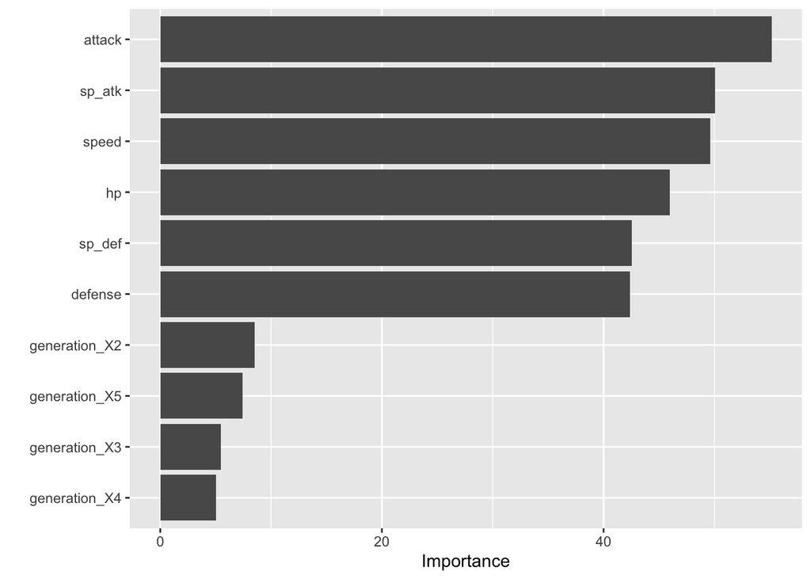

```r
library(vip)
best_rf_params <- show_best(rf_results, metric = "roc_auc", n = 1)
best_rf_spec <- rand_forest(
                    mtry = best_rf_params$mtry,
                    trees = best_rf_params$trees,
                    min_n = best_rf_params$min_n) %>%
                    set_engine("ranger",importance = "impurity") %>%
                    set_mode("classification")

best_rf_workflow <- workflow() %>%
                    add_recipe(pokemon_recipe) %>%
                    add_model(best_rf_spec)

best_rf_fit <- best_rf_workflow %>%
               fit(data = pokemon_train)

best_rf_model <- pull_workflow_fit(best_rf_fit)
vip(best_rf_model)
```

```r
# Predict the class labels
predicted_labels <- predict(best_rf_fit, new_data = pokemon_test) %>% pull()

# Predict the probabilities
predicted_probs <- predict(best_rf_fit, new_data = pokemon_test, type = "prob") %>% pull()
```

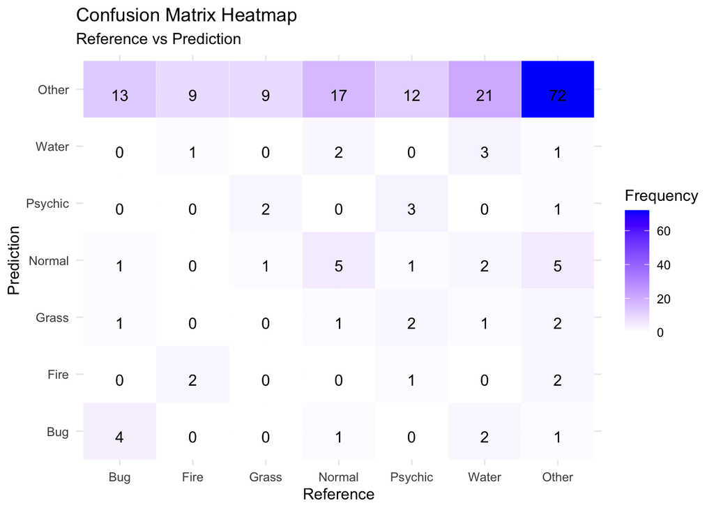

```r
library(caret)
conf_mat <- confusionMatrix(predicted_labels, pokemon_test$type_1)

# Create heatmap
# Convert the confusion matrix to tidy format
conf_mat_df <- as.table(as.matrix(conf_mat$table)) %>% as.data.frame()

# Create heatmap using ggplot2
ggplot(data = conf_mat_df, aes(x = Reference, y = Prediction)) +
  geom_tile(aes(fill = Freq), color = "white") +
  geom_text(aes(label = sprintf("%d", Freq)), vjust = 1) +
  scale_fill_gradient(low = "white", high = "blue") +
  theme_minimal() +
  labs(fill = "Frequency",
       title = "Confusion Matrix Heatmap",
       subtitle = "Reference vs Prediction")
```

### Exercise 10

How did your best random forest model do on the testing set?

Which Pokemon types is the model best at predicting, and which is it worst at? (Do you have any ideas why this might be?)